# R Notebook

First, read excel file.

Check header

```r
head(df)
```

```
##   schoolar  id C
## 1        1 557 O
## 2        1 596 O
## 3        1 639 O
## 4        1 710 O
## 5        0  NA O
## 6        0  NA O
##                                                                                                                       publication
## 1                                            Measuring fire severity using UAV imagery in semi-arid central Queensland, Australia
## 2                                                     Fire detection using infrared images for UAV-based forest fire surveillance
## 3 Aerial Images-Based Forest Fire Detection for Firefighting Using Optical Remote Sensing Techniques and Unmanned Aerial Vehicles
## 4                                                                            Using low-cost drones to map malaria vector habitats
## 5                                                                                         Flooded area detection using UAV images
## 6                        Unmanned aerial vehicle systems for remote estimation of flooded areas based on complex image processing
##                               cite ncites year            type
```

[output cut: 55 more lines]

We subset those NO NA values:

- Per category
- Per RPAS type
- Per both

```r
library(dplyr)
df2 <- df %>%
  subset(!is.na(category) & !is.na(RPAS.type))  %>%
  group_by(category,RPAS.type) %>%
  summarise(count=n()) %>%
  mutate(perc=count/sum(count))

df.ecosystem <- df %>%
  subset(!is.na(category) & !is.na(ecosystem))  %>%
  group_by(category,ecosystem) %>%
  summarise(count=n()) %>%
  mutate(perc=count/sum(count))

df3 <- df %>%
  subset(!is.na(RPAS.type))  %>%
  group_by(RPAS.type)  %>%
  summarise(count=n()) %>%
  mutate(perc2=count/sum(count))

df4 <- df %>%
  subset(!is.na(category))  %>%
  group_by(category)  %>%
  summarise(count=n()) %>%
  mutate(perc3=count/sum(count))
```

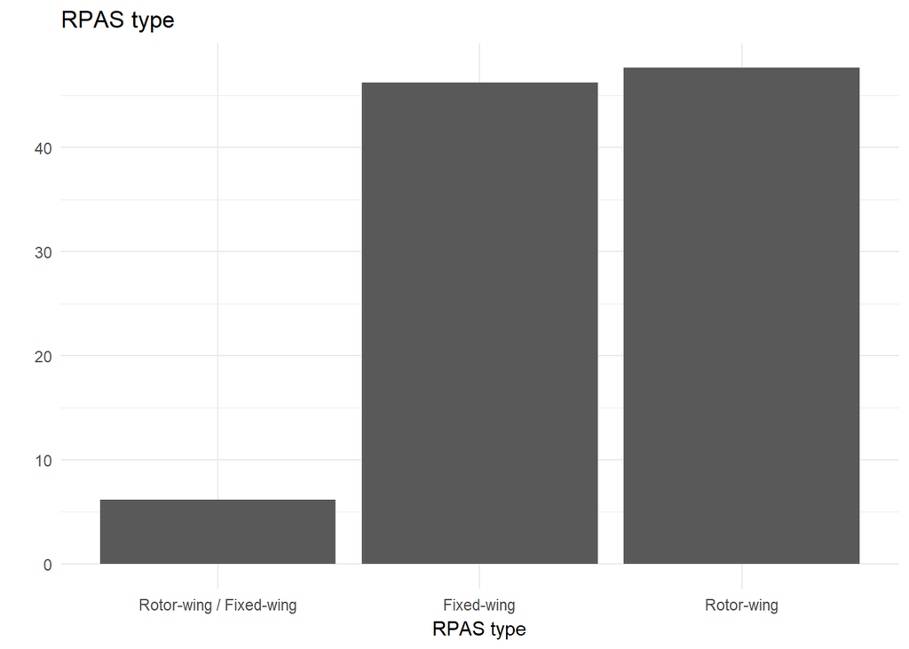

```r
require(ggplot2)
ggplot(data= df3, aes(x=reorder(RPAS.type, perc2*100), y = perc2*100)) +

  geom_bar(stat="identity") +

  labs(title = "RPAS type", y = "", x="RPAS type") +

  theme_minimal()
```

[figure not shown]

```r
ggplot(data= df4, aes(x=reorder(category, perc3*100), y = perc3*100)) +

  geom_bar(stat="identity") +

  labs(title = "RPAS Category", y = "", x="Category") +

  theme_minimal()
```

[figure not shown]

```r
ggplot(data=df2,aes(x=category, y = perc*100, fill=as.factor(RPAS.type))) +
    geom_bar(stat="identity") +
  #  coord_flip() +
    labs(x = "Study category", y = "Percent", fill = "RPAS type") +
    theme_minimal(base_size = 14)
```

Ecosystems

[figure not shown]

```r
ggplot(data=df.ecosystem,aes(x=category, y = perc*100, fill=as.factor(ecosystem))) +
    geom_bar(stat="identity") +
  #  coord_flip() +
    labs(x = "Study category", y = "Percent", fill = "ecosystem") +
    theme_minimal(base_size = 14)
```

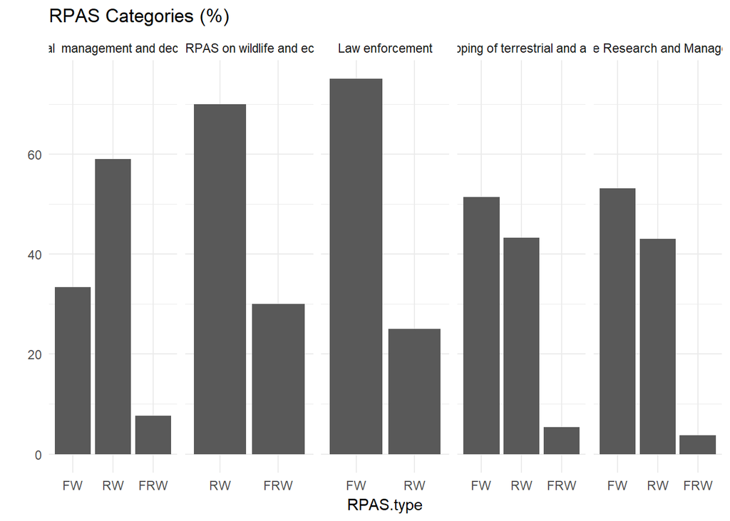

```r
levels(df2$RPAS.type) <- c("FW", "RW", "FRW")

ggplot(data=subset(df2,category !="Other" & category !="Ecotourism"), aes(x=RPAS.type, y=perc*100)) +
  geom_bar(stat="identity") +
  labs(title = "RPAS Categories (%)", y = "") +
  facet_grid(. ~category , scales = "free") +

   theme_minimal()
```

Plot percent of studies in each category

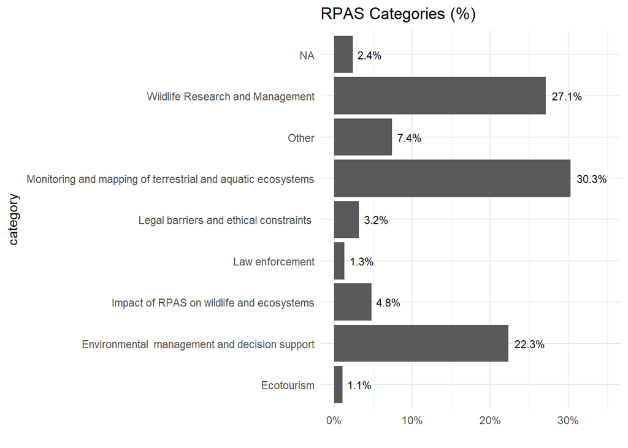

```r
ggplot(df, aes(x = category)) +

  geom_bar(aes(y = (..count..)/sum(..count..))) +

  coord_flip() +

  scale_y_continuous(labels = scales::percent, limits = c(0,0.35)) +

  geom_text(aes(y = ((..count..)/sum(..count..)),
          label = scales::percent((..count..)/sum(..count..))),
          stat = "count", hjust = -0.20,  size=3) +

  labs(title = "RPAS Categories (%)", y = "") +

  theme_minimal()
```

How many publications per year?

```r
df5 <- df %>%
  mutate(higher_2010 = as.numeric(as.character(df$year)) >= 2010)  %>%
  subset(!is.na(df$year) & higher_2010)

droplevels(df5)$year
```

```
##   [1] 2017 2017 2017 2017 2017 2017 2017 2017 2017 2017 2017 2017 2017 2017
##  [15] 2015 2017 2017 2016 2015 2017 2017 2017 2016 2010 2017 2017 2017 2017
##  [29] 2017 2016 2015 2017 2017 2013 2017 2015 2017 2017 2016 2017 2015 2014
##  [43] 2016 2016 2013 2017 2017 2015 2016 2014 2017 2017 2017 2017 2015 2015
##  [57] 2017 2015 2016 2017 2015 2016 2017 2017 2017 2014 2017 2017 2017 2017
##  [71] 2017 2017 2017 2017 2017 2016 2010 2016 2017 2015 2017 2017 2017 2017
##  [85] 2015 2017 2017 2017 2017 2017 2017 2017 2012 2016 2015 2017 2017 2017
##  [99] 2017 2017 2016 2016 2016 2015 2016 2015 2017 2017 2017 2010 2017 2017
## [113] 2017 2017 2017 2017 2017 2014 2017 2014 2017 2017 2017 2015 2016 2015
## [127] 2015 2015 2012 2016 2017 2015 2015 2016 2015 2015 2015 2015 2012 2017
## [141] 2017 2016 2016 2017 2013 2012 2015 2012 2017 2017 2017 2012 2016 2015
## [155] 2016 2016 2016 2017 2015 2017 2016 2016 2016 2016 2016 2016 2016 2016
## [169] 2016 2016 2016 2016 2016 2016 2017 2016 2016 2016 2016 2016 2016 2016
## [183] 2016 2016 2016 2016 2016 2016 2016 2016 2017 2016 2016 2016 2016 2015
## [197] 2015 2015 2015 2015 2015 2015 2017 2016 2016 2015 2015 2015 2016 2015
## [211] 2015 2015 2017 2015 2015 2016 2016 2016 2013 2013 2013 2012 2016 2015
## [225] 2014 2013 2015 2016 2016 2016 2016 2016 2016 2016 2016 2016 2015 2015
## [239] 2016 2016 2016 2014 2016 2012 2015 2017 2017 2014 2016 2017 2016 2016
## [253] 2014 2016 2016 2015 2015 2015 2015 2015 2015 2013 2014 2013 2011 2011
## [267] 2011 2010 2016 2015 2015 2015 2015 2013 2014 2015 2014 2014 2014 2014
## [281] 2014 2014 2014 2013 2013 2013 2013 2015 2016 2015 2013 2015 2016 2012
## [295] 2015 2015 2015 2015 2012 2017 2016 2015 2015 2015 2014 2014 2014 2012
## [309] 2011 2014 2014 2012 2014 2010 2014 2014 2015 2016 2014 2014 2014 2014
## [323] 2013 2013 2012 2012 2013 2012 2013 2012 2012 2012 2014 2014 2015 2015
## [337] 2010 2011 2012 2010 2015 2011 2011 2015 2011 2017 2017 2010 2017 2015
## [351] 2014 2013 2017 2017 2017
## Levels: 2010 2011 2012 2013 2014 2015 2016 2017
```

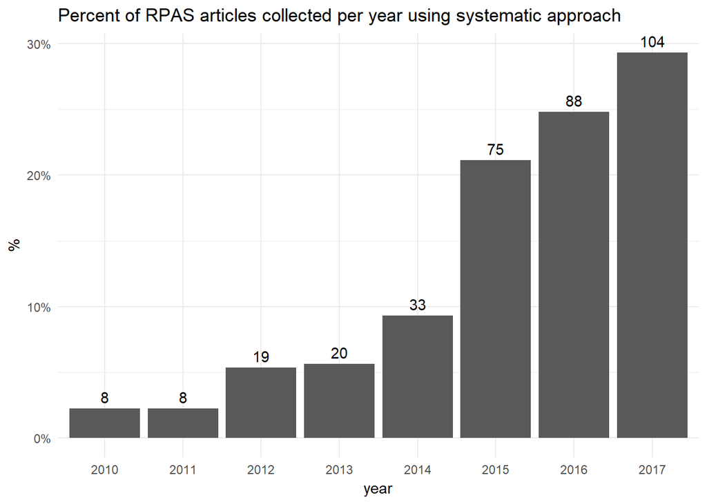

```r
ggplot(data=df5, aes(x=year)) +
  geom_bar(aes(y = (..count..)/sum(..count..))) +
  geom_text(aes(label = ..count.., y= (..count..)/sum(..count..)), stat= "count", vjust = -.5) +
  scale_y_continuous(labels = scales::percent) +
  theme_minimal() +
  labs(title = "Percent of RPAS articles collected per year using systematic approach", x="year", y = "%")
```

Word cloud

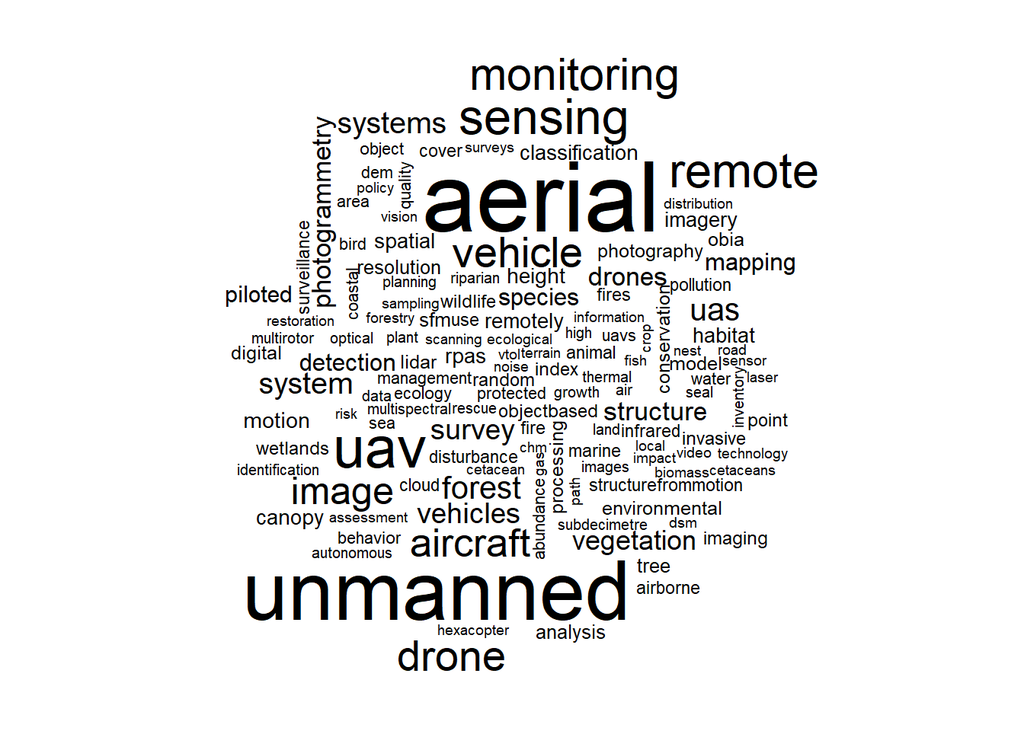

```r
require(wordcloud)
require(tm)
keywords <- as.vector(subset(df$keywords, !is.na(df$keywords)))

keywords <- paste(keywords, collapse =",")


wordcloud(keywords)
```

The 5 main steps to create word clouds in R

## Step 1: Create a text file (txt)

```r
write.csv2(keywords, file= "export.txt")
```

## Step 2 : Install and load the required packages

```r
# http://www.sthda.com/english/wiki/text-mining-and-word-cloud-fundamentals-in-r-5-simple-steps-you-should-know

# Install
require("tm")  # for text mining
require("SnowballC") # for text stemming
require("wordcloud") # word-cloud generator
require("RColorBrewer") # color palettes
```

## Step 3 : Text mining

load the text

The text is loaded using Corpus() function from text mining (tm) package. Corpus is a list of a document (in our case, we only have one document).

We start by importing the text file created in Step 1

```r
text <- readLines("export.txt")
```

Load the data as a corpus

```r
# Load the data as a corpus
docs <- Corpus(VectorSource(text))
```

Inspect the content of the document

```r
inspect(docs)
```

```
## <<SimpleCorpus>>
## Metadata:  corpus specific: 1, document level (indexed): 0
## Content:  documents: 9
##
## [1] "";"x"
## [2] "1";"Optical imaging, Fires, Cameras, Visualization, Image processing, Monitoring, Fuels ,Unmanned aerial vehicles, Forest fires, Optical flow, Optical remote sensing, Fire detection, Image processing,Malaria, Drones, Earth observation, Malaria vector habitats, Larval source managemen,feature…
## [3] Invasive alien plants, UAV, Harrisia pomanensis, Point- and area-based accuracy assessment,UAV lidar, grasslands, canopy height, fractional cover, aboveground biomass,UAVs, UASs, drones, environmental monitoring, coastal habitats, mapping, aerial photography, photogrammetry, image classificat…
## [4] ,Drone, Unmanned aircraft systems, Search and rescue, Mountain rescue,UAV, DEM, LAI, chlorophyll content, vegetation index, grassland,Miconia calvescens, Hawaii, Oblique, Canopy openness, UAS, Plant detection,Privacy, Data protection, Industry Regulation,Index of abundance, monitoring noise, …
## [5] ,Structure from motion (SFM), 3D modelling, Tree delineation, Crown diameter, DEM, Airborne data, Drone, UAS,Inaccessible Island, Tristan Albatross, Tristan da Cunha, unmanned aerial vehicle,aerial survey, drone, image processing, object-based image analysis, Odocoileus virginianus, remote se…
## [6] conversion,
## [7] fragmentation, drone, protected areas, Democratic Republic of Congo,Drone Nursery Mapping, Image classification, Aerial imagery, Mediterranean Sea, Central Tyrrhenian Sea, Giglio Island,UAV, hyperspectral, photogrammetry, radiometry, point cloud, forest, classification,UAS, forest inventory, …
## [8] Introduction,UAS, remote sensing, environment, review,autonomous flying, biodiversity, canopy gaps, drone, polygon-based pair correlation function, remotely piloted vehicles, RPV, unmanned aircraft systems, UAS, UAV,Payload, Precision agriculture, RPAS, UAV, Vegetation indices, river, remote …
## [9] Source, commercial, Orthomosaic, DEM, precision, performance, comparison, RGB, NIR,biodiversity, coarse-filter approach, forest understorey, gap shape complexity index, unmanned aerial vehicles,Remote sensing, R software, Machine learning, Random forest, Support vector machine, RPAS, Land use…
```

Text transformation

Transformation is performed using tm_map() function to replace, for example, special characters from the text.

Replacing “/”, “@” and “|” with space:

```r
toSpace <- content_transformer(function (x , pattern ) gsub(pattern, " ", x))
docs <- tm_map(docs, toSpace, "/")
docs <- tm_map(docs, toSpace, "@")
docs <- tm_map(docs, toSpace, "\\|")
```

Cleaning the text

the tm_map() function is used to remove unnecessary white space, to convert the text to lower case, to remove common stopwords like ‘the’, “we”.

The information value of ‘stopwords’ is near zero due to the fact that they are so common in a language. Removing this kind of words is useful before further analyses. For ‘stopwords’, supported languages are danish, dutch, english, finnish, french, german, hungarian, italian, norwegian, portuguese, russian, spanish and swedish. Language names are case sensitive.

I’ll also show you how to make your own list of stopwords to remove from the text.

You could also remove numbers and punctuation with removeNumbers and removePunctuation arguments.

Another important preprocessing step is to make a text stemming which reduces words to their root form. In other words, this process removes suffixes from words to make it simple and to get the common origin. For example, a stemming process reduces the words “moving”, “moved” and “movement” to the root word, “move”.

Note that, text stemming require the package ‘SnowballC’.

The R code below can be used to clean your text :

```r
# Convert the text to lower case
docs <- tm_map(docs, content_transformer(tolower))
# Remove numbers
docs <- tm_map(docs, removeNumbers)
# Remove english common stopwords
docs <- tm_map(docs, removeWords, stopwords("english"))
# Remove your own stop word
# specify your stopwords as a character vector
docs <- tm_map(docs, removeWords, c("uav", "aerial", "unmanned"))
# Remove punctuations
docs <- tm_map(docs, removePunctuation)
# Eliminate extra white spaces
docs <- tm_map(docs, stripWhitespace)
# Text stemming
# docs <- tm_map(docs, stemDocument)
```

## Step 4 : Build a term-document matrix

```r
dtm <- TermDocumentMatrix(docs)
m <- as.matrix(dtm)
v <- sort(rowSums(m),decreasing=TRUE)
d <- data.frame(word = names(v),freq=v)
head(d, 10)
```

```
##                  word freq
## sensing       sensing   45
## remote         remote   43
## monitoring monitoring   39
## vehicle       vehicle   37
## drone           drone   36
## aircraft     aircraft   32
## image           image   30
## systems       systems   25
## uas               uas   24
## forest         forest   23
```

## Step 5 : Generate the Word cloud

The importance of words can be illustrated as a word cloud as follow :

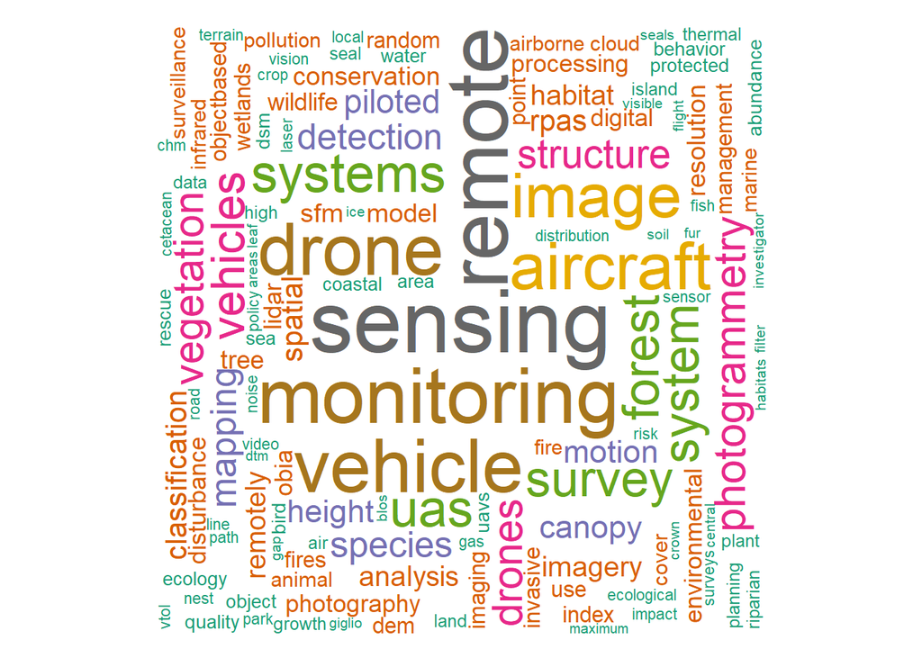

```r
set.seed(1234)
wordcloud(words = d$word, freq = d$freq, min.freq = 1,
          max.words=200, random.order=FALSE, rot.per=0.35,
          colors=brewer.pal(8, "Dark2"))
```